# Physics-Informed Deep Inverse Reconstruction for Lensless Phase-Mask Imaging

**A self-contained, runnable tutorial and notebook.**

This notebook is a complete implementation of a lensless computational imaging pipeline. It models how a mask-based ("DiffuserCam"-style) lensless camera forms an image, and compares three ways of inverting that process to recover the scene:

1. **Wiener deconvolution** — classical, closed-form, fast.
2. **ADMM with a Total Variation (TV) prior** — classical, iterative, model-based.
3. **Unrolled ADMM network** — physics-informed deep learning, where the *structure* of ADMM is kept but the hand-designed TV proximal step is replaced by a learned CNN denoiser, and hyperparameters (like the penalty `ρ`) become learnable.

Everything below — PSF simulation, the forward optical model, classical solvers, the neural network, training loop, and evaluation — is implemented **inline in this notebook**. There is no external repo to clone and no `src/` package to import: just run the cells top to bottom.

[output not shown]

## Part 0 — Setup

No extra oridinary requirements

```python
# If a package is missing (e.g. running outside Colab), this installs it quietly.
import importlib, subprocess, sys

def _ensure(pkg, import_name=None):
    import_name = import_name or pkg
    try:
        importlib.import_module(import_name)
    except ImportError:
        subprocess.run([sys.executable, "-m", "pip", "install", "-q", pkg], check=True)

for pkg in ["torch", "numpy", "matplotlib"]:
    _ensure(pkg)

print("Environment ready.")
```

```
Environment ready.
```

```python
import math
import time
import numpy as np
import torch
import torch.nn as nn
import torch.nn.functional as F
import matplotlib.pyplot as plt
for pkg in ["torch", "numpy", "matplotlib", "scikit-image"]:
    _ensure(pkg, "skimage" if pkg == "scikit-image" else pkg)

plt.rcParams['figure.figsize'] = (12, 4)
plt.rcParams['figure.dpi'] = 110
plt.rcParams['image.cmap'] = 'gray'

SEED = 42
np.random.seed(SEED)
torch.manual_seed(SEED)

device = torch.device('cuda' if torch.cuda.is_available() else 'cpu')
print(f"PyTorch {torch.__version__} | device = {device}")

# ---- Global experiment settings (feel free to tune) ----
IMG_SIZE   = 128      # scene / measurement resolution (increase to 96/128 for nicer results, slower)
NOISE_STD  = 0.003    # sensor (Gaussian) noise standard deviation
PSF_FEATURE_SIZE = 4.0  # controls the "grain" of the simulated phase-mask PSF (smaller = finer caustic)
```

```
PyTorch 2.11.0+cu128 | device = cuda
```

## Part 1 Simulating a Phase-Mask PSF

A lensless camera replaces the lens with a **phase mask**: a thin optical element that imparts a spatially-varying phase delay on incoming light. Because there's no lens to focus light to a point, a single point source in the scene produces a complex speckle/caustic pattern on the sensor — the camera's **Point Spread Function (PSF)**.

We simulate this physically: start from a random phase screen, upsample it smoothly (real phase masks vary smoothly at the micro-feature scale), treat it as a complex field `exp(iφ)`, and propagate it to the far field with a Fourier transform (a standard Fraunhofer-diffraction approximation). The **squared magnitude** of that propagated field is the sensor-plane intensity pattern — our PSF.

The forward optical model throughout this notebook is:

```
y = PSF ⊛ x + n
```

i.e. the sensor measurement is the scene convolved with this PSF, plus noise.

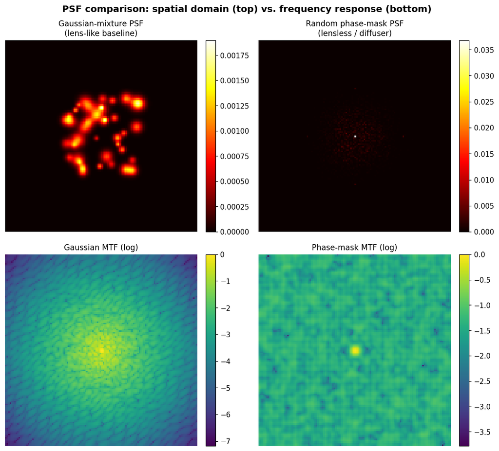

[output not shown]

```python
def generate_phase_mask_psf(size=64, feature_size=4.0, seed=0):
    '''Simulate a diffuser / phase-mask PSF via Fraunhofer propagation of a random phase screen.

    A coarse random phase pattern is generated and smoothly upsampled (mimicking the
    correlation length of a real diffuser's micro-structure), then propagated to the far
    field via an FFT. The resulting intensity pattern is the simulated PSF.
    '''
    rng = np.random.RandomState(seed)
    low_res = max(4, int(size / feature_size))
    phase_low = rng.uniform(0, 2 * np.pi, size=(low_res, low_res)).astype(np.float32)

    phase_t = torch.from_numpy(phase_low).float()[None, None]
    phase_full = F.interpolate(phase_t, size=(size, size), mode='bicubic',
                                align_corners=False)[0, 0].numpy()

    field = np.exp(1j * phase_full)                     # complex field after the phase mask
    far_field = np.fft.fftshift(np.fft.fft2(field))      # Fraunhofer propagation to sensor plane
    psf = np.abs(far_field) ** 2                         # sensor measures intensity
    psf = psf / psf.sum()                                 # energy-conserving normalization
    return psf.astype(np.float32)


def gaussian_mixture_psf(size=64, num_components=40, seed=0):
    '''A softer, more 'lens-like' PSF baseline: a sum of randomly placed 2D Gaussians.'''
    rng = np.random.RandomState(seed)
    yy, xx = np.mgrid[0:size, 0:size]
    psf = np.zeros((size, size), dtype=np.float32)
    for _ in range(num_components):
        cy, cx = rng.uniform(size * 0.3, size * 0.7, size=2)
        sigma = rng.uniform(1.0, 3.0)
        amp = rng.uniform(0.5, 1.0)
        psf += amp * np.exp(-((yy - cy) ** 2 + (xx - cx) ** 2) / (2 * sigma ** 2))
    psf = psf / psf.sum()
    return psf.astype(np.float32)


psf_phase = generate_phase_mask_psf(IMG_SIZE, PSF_FEATURE_SIZE, seed=SEED)
psf_gauss = gaussian_mixture_psf(IMG_SIZE, num_components=40, seed=SEED)

fig, axes = plt.subplots(2, 2, figsize=(10, 9))
for ax, psf, title in zip(axes[0], [psf_gauss, psf_phase],
                           ['Gaussian-mixture PSF\n(lens-like baseline)', 'Random phase-mask PSF\n(lensless / diffuser)']):
    im = ax.imshow(psf, cmap='hot')
    ax.set_title(title, fontsize=11)
    ax.axis('off')
    plt.colorbar(im, ax=ax, fraction=0.046, pad=0.04)

for ax, psf, title in zip(axes[1], [psf_gauss, psf_phase], ['Gaussian MTF (log)', 'Phase-mask MTF (log)']):
    psf_n = psf / psf.sum()
    mtf = np.abs(np.fft.fftshift(np.fft.fft2(psf_n)))
    im = ax.imshow(np.log10(mtf + 1e-8), cmap='viridis')
    ax.set_title(title, fontsize=11)
    ax.axis('off')
    plt.colorbar(im, ax=ax, fraction=0.046, pad=0.04)

plt.suptitle('PSF comparison: spatial domain (top) vs. frequency response (bottom)', fontsize=13, fontweight='bold')
plt.tight_layout()
plt.show()

print("Notice the phase-mask PSF spreads energy much more broadly in both space and frequency —")
print("this is exactly what makes lensless imaging possible: information about every scene point")
print("is multiplexed across many sensor pixels, and a broad frequency response means fewer")
print("frequencies are completely lost (no 'spectral nulls').")

# This is the PSF we'll use for the rest of the notebook
psf = psf_phase
```

## Part 2 — The Forward Imaging Model

Convolution is a per-pixel-costly operation done naively, but is a single element-wise multiplication in the Fourier domain (the convolution theorem):

```
y = PSF ⊛ x + n   ⟺   Y(f) = H(f) · X(f) + N(f)
```

We implement this as a differentiable `torch.nn.Module` so it can be reused both to *simulate* measurements and — since it is differentiable — inside the unrolled network in Part 4.

[figure not shown]

[output not shown]

```python
class ForwardModel(nn.Module):
    '''Lensless imaging forward model: y = circular_conv(x, psf) + noise, via FFT.'''

    def __init__(self, psf: np.ndarray, noise_std: float = 0.003):
        super().__init__()
        psf_t = torch.from_numpy(np.fft.ifftshift(psf)).float()
        psf_fft = torch.fft.fft2(psf_t)
        self.register_buffer('psf_fft', psf_fft)
        self.register_buffer('psf_fft_conj', torch.conj(psf_fft))
        self.register_buffer('psf_fft_abs_sq', psf_fft.real ** 2 + psf_fft.imag ** 2)
        self.noise_std = noise_std

    def forward(self, x: torch.Tensor, add_noise: bool = True) -> torch.Tensor:
        # x: (B, 1, H, W)
        x_fft = torch.fft.fft2(x.squeeze(1))
        y = torch.fft.ifft2(x_fft * self.psf_fft.unsqueeze(0)).real.unsqueeze(1)
        if add_noise and self.noise_std > 0:
            y = y + self.noise_std * torch.randn_like(y)
        return y


def make_scene(size=64, kind='shapes', seed=0):
    '''Generate a synthetic test scene. kind in {'checkerboard', 'target', 'shapes'}.'''
    rng = np.random.RandomState(seed)
    img = np.zeros((size, size), dtype=np.float32)

    if kind == 'checkerboard':
        n = 8
        block = size // n
        for i in range(n):
            for j in range(n):
                if (i + j) % 2 == 0:
                    img[i*block:(i+1)*block, j*block:(j+1)*block] = 1.0

    elif kind == 'target':
        yy, xx = np.mgrid[0:size, 0:size]
        r = np.sqrt((yy - size/2) ** 2 + (xx - size/2) ** 2)
        img = (np.sin(r * 0.9) > 0).astype(np.float32)

    else:  # 'shapes' — smooth background + a handful of sharp blobs, natural-image-ish
        base = rng.rand(size, size).astype(np.float32)
        base_t = torch.from_numpy(base)[None, None]
        smooth = F.avg_pool2d(F.pad(base_t, (3, 3, 3, 3), mode='reflect'), 7, stride=1)
        img = smooth[0, 0].numpy()
        img = (img - img.min()) / (img.max() - img.min() + 1e-8)
        for _ in range(4):
            cy, cx = rng.randint(10, size - 10), rng.randint(10, size - 10)
            rad = rng.randint(4, 10)
            yy, xx = np.mgrid[0:size, 0:size]
            mask = (yy - cy) ** 2 + (xx - cx) ** 2 < rad ** 2
            img[mask] = rng.rand()

    return np.clip(img, 0, 1).astype(np.float32)
from skimage import data, transform, color

def load_real_scene(name, size):
    img = getattr(data, name)()
    if img.ndim == 3:
        img = color.rgb2gray(img)
    img = transform.resize(img, (size, size), anti_aliasing=True)
    return ((img - img.min()) / (img.max() - img.min() + 1e-8)).astype(np.float32)

# Build the shared forward model used throughout the notebook
forward_model = ForwardModel(psf, noise_std=NOISE_STD).to(device)

sscenes = {name: load_real_scene(name, IMG_SIZE) for name in ['chelsea', 'astronaut']}

fig, axes = plt.subplots(2, 3, figsize=(13, 8))
for col, (name, scene) in enumerate(scenes.items()):
    x = torch.from_numpy(scene)[None, None].to(device)
    y = forward_model(x)

    axes[0, col].imshow(scene, vmin=0, vmax=1)
    axes[0, col].set_title(f'Scene: {name}', fontsize=11)
    axes[0, col].axis('off')

    axes[1, col].imshow(y.squeeze().cpu().numpy())
    axes[1, col].set_title(f'Measurement (σ={NOISE_STD})', fontsize=11)
    axes[1, col].axis('off')

plt.suptitle('Forward model: scene → lensless sensor measurement', fontsize=13, fontweight='bold')
plt.tight_layout()
plt.show()

print("Every measurement looks like an unrecognizable speckle pattern — but all the scene")
print("information is still there, multiplexed across the sensor. Reconstruction is the")
print("process of inverting this multiplexing.")
```

## Part 3 — Quality Metrics: PSNR & SSIM

Before comparing reconstruction methods we need a way to score them:

- **PSNR** (Peak Signal-to-Noise Ratio, dB) — directly penalizes pixel-wise error; higher is better.
- **SSIM** (Structural Similarity) — compares local luminance, contrast, and structure using a sliding Gaussian window; more aligned with perceived quality.

Both are implemented here directly in PyTorch (no extra dependency).

```python
def compute_psnr(x: torch.Tensor, y: torch.Tensor, max_val: float = 1.0) -> float:
    mse = F.mse_loss(x, y).item()
    return 100.0 if mse == 0 else 10 * math.log10(max_val ** 2 / mse)


def _gaussian_kernel(ksize=11, sigma=1.5):
    coords = torch.arange(ksize).float() - ksize // 2
    g = torch.exp(-(coords ** 2) / (2 * sigma ** 2))
    g = g / g.sum()
    return (g[:, None] @ g[None, :])[None, None]

_SSIM_KERNEL = _gaussian_kernel()

def compute_ssim(x: torch.Tensor, y: torch.Tensor, C1=0.01 ** 2, C2=0.03 ** 2) -> float:
    k = _SSIM_KERNEL.to(device=x.device, dtype=x.dtype)
    pad = k.shape[-1] // 2
    mu_x, mu_y = F.conv2d(x, k, padding=pad), F.conv2d(y, k, padding=pad)
    mu_x2, mu_y2, mu_xy = mu_x * mu_x, mu_y * mu_y, mu_x * mu_y
    sigma_x2 = F.conv2d(x * x, k, padding=pad) - mu_x2
    sigma_y2 = F.conv2d(y * y, k, padding=pad) - mu_y2
    sigma_xy = F.conv2d(x * y, k, padding=pad) - mu_xy
    ssim_map = ((2 * mu_xy + C1) * (2 * sigma_xy + C2)) / ((mu_x2 + mu_y2 + C1) * (sigma_x2 + sigma_y2 + C2))
    return ssim_map.mean().item()


def grad_xy(u: torch.Tensor):
    dx = torch.zeros_like(u); dx[:, :, :-1, :] = u[:, :, 1:, :] - u[:, :, :-1, :]
    dy = torch.zeros_like(u); dy[:, :, :, :-1] = u[:, :, :, 1:] - u[:, :, :, :-1]
    return dx, dy

def total_variation(x: torch.Tensor) -> torch.Tensor:
    '''Mean anisotropic TV — used both as a training regularizer and to characterize images.'''
    dx, dy = grad_xy(x)
    return torch.sqrt(dx ** 2 + dy ** 2 + 1e-8).mean()


# sanity check: identical images
_test = torch.rand(1, 1, 32, 32)
print(f"PSNR(x, x) = {compute_psnr(_test, _test):.1f} dB  (should be very high)")
print(f"SSIM(x, x) = {compute_ssim(_test, _test):.4f}  (should be 1.0)")
```

```
PSNR(x, x) = 100.0 dB  (should be very high)
SSIM(x, x) = 1.0000  (should be 1.0)
```

## Part 4 — Classical Reconstruction

### 4.1 Wiener Deconvolution

The closed-form linear estimator in the frequency domain:

```
X̂(f) = [ H*(f) / (|H(f)|² + λ) ] · Y(f)
```

where `H*` is the complex conjugate of the PSF's Fourier transform and `λ` is a regularization constant that trades off noise amplification against blur. One FFT pair — extremely fast, but with no prior on what natural images look like.

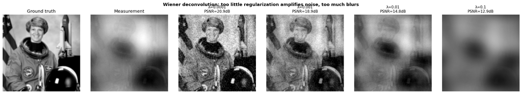

```python
def wiener_deconv(y: torch.Tensor, fwd: ForwardModel, reg: float = 1e-3) -> torch.Tensor:
    y_fft = torch.fft.fft2(y.squeeze(1))
    X = (fwd.psf_fft_conj / (fwd.psf_fft_abs_sq + reg)) * y_fft
    x_hat = torch.fft.ifft2(X).real.unsqueeze(1)
    return x_hat.clamp(0, 1)


# --- sweep the regularization parameter on the 'shapes' scene ---
scene = scenes['astronaut']
x_gt = torch.from_numpy(scene)[None, None].to(device)
y_meas = forward_model(x_gt)

reg_values = [1e-4, 1e-3, 1e-2, 1e-1]
fig, axes = plt.subplots(1, len(reg_values) + 2, figsize=(20, 3.6))

axes[0].imshow(scene, vmin=0, vmax=1); axes[0].set_title('Ground truth'); axes[0].axis('off')
axes[1].imshow(y_meas.squeeze().cpu().numpy()); axes[1].set_title('Measurement'); axes[1].axis('off')

for i, reg in enumerate(reg_values):
    recon = wiener_deconv(y_meas, forward_model, reg=reg)
    p = compute_psnr(recon, x_gt)
    axes[i + 2].imshow(recon.squeeze().cpu().numpy(), vmin=0, vmax=1)
    axes[i + 2].set_title(f'λ={reg}\nPSNR={p:.1f}dB', fontsize=10)
    axes[i + 2].axis('off')

plt.suptitle('Wiener deconvolution: too little regularization amplifies noise, too much blurs', fontsize=12, fontweight='bold')
plt.tight_layout()
plt.show()
```

### 4.2 ADMM with a Total-Variation Prior

ADMM lets us add a **prior** knowledge about what natural images look like instead of relying purely on the linear model. We use Total Variation (TV): *"natural images are mostly flat with occasional sharp edges."*

We solve:

```
minimize_x   (1/2)||y - PSF ⊛ x||² + λ·TV(x)
```

by alternating:

1. **x-update** a data-fidelity least-squares solve, closed-form in the Fourier domain (like Wiener, but pulled toward the current auxiliary variable `z`).
2. **z-update** apply the TV proximal operator to `x + u` (this is where the "denoising" happens).
3. **u-update** update the ADMM dual/scaled-residual variable.

The TV proximal operator itself is solved by projected/smoothed gradient descent on

```
prox_TV(v) = argmin_x  (1/2)||x - v||² + λ·TV(x)
```

which we verify against autograd below before using it, to make sure the hand-derived gradient is correct.

```
Max difference between autograd and hand-derived TV gradient: 2.38e-07  (should be ~1e-6 or smaller)
```

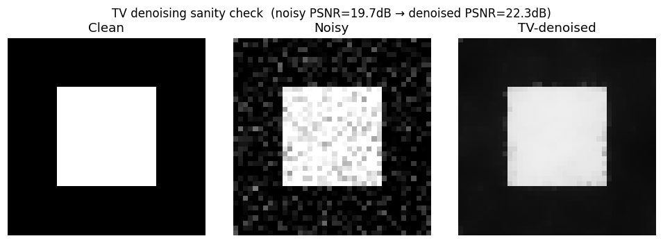

```python
def adjoint_grad(px: torch.Tensor, py: torch.Tensor) -> torch.Tensor:
    '''Adjoint of the forward-difference gradient operator used in grad_xy (i.e. -divergence).'''
    adjx = -px.clone(); adjx[:, :, 1:, :] += px[:, :, :-1, :]
    adjy = -py.clone(); adjy[:, :, :, 1:] += py[:, :, :, :-1]
    return adjx + adjy


def tv_energy(x, v, lam, eps=1e-6):
    dx, dy = grad_xy(x)
    tv = torch.sqrt(dx ** 2 + dy ** 2 + eps).sum()
    return 0.5 * ((x - v) ** 2).sum() + lam * tv


def tv_prox(v, lam, n_iters=40, eps=1e-4):
    L = 1.0 + lam * 8.0 / (eps ** 0.5)   # Lipschitz bound → safe step size
    step = 1.0 / L
    x = v.clone(); z = v.clone(); t = 1.0
    for _ in range(n_iters):
        dx, dy = grad_xy(z)
        norm = torch.sqrt(dx ** 2 + dy ** 2 + eps)
        px, py = dx / norm, dy / norm
        grad_e = (z - v) + lam * adjoint_grad(px, py)
        x_new = z - step * grad_e
        t_new = (1 + (1 + 4 * t * t) ** 0.5) / 2
        z = x_new + ((t - 1) / t_new) * (x_new - x)
        x, t = x_new, t_new
    return x


# --- Verify the hand-derived TV gradient against autograd ---
torch.manual_seed(1)
x0 = torch.randn(1, 1, 10, 10, requires_grad=True)
v0 = torch.randn(1, 1, 10, 10)
lam_test = 0.3
E = tv_energy(x0, v0, lam_test)
E.backward()
with torch.no_grad():
    dx, dy = grad_xy(x0)
    norm = torch.sqrt(dx ** 2 + dy ** 2 + 1e-6)
    manual_grad = (x0 - v0) + lam_test * adjoint_grad(dx / norm, dy / norm)
max_diff = (x0.grad - manual_grad).abs().max().item()
print(f"Max difference between autograd and hand-derived TV gradient: {max_diff:.2e}  (should be ~1e-6 or smaller)")

# --- Demonstrate TV denoising on a noisy synthetic image ---
clean = torch.zeros(1, 1, 40, 40); clean[:, :, 10:30, 10:30] = 1.0
noisy = (clean + 0.15 * torch.randn_like(clean)).clamp(0, 1)
denoised = tv_prox(noisy, lam=0.15, n_iters=120)

fig, axes = plt.subplots(1, 3, figsize=(9, 3.2))
for ax, img, title in zip(axes, [clean, noisy, denoised], ['Clean', 'Noisy', 'TV-denoised']):
    ax.imshow(img.squeeze().numpy(), vmin=0, vmax=1); ax.set_title(title); ax.axis('off')
plt.suptitle(f'TV denoising sanity check  (noisy PSNR={compute_psnr(noisy, clean):.1f}dB → denoised PSNR={compute_psnr(denoised, clean):.1f}dB)', fontsize=11)
plt.tight_layout(); plt.show()
```

```
Running ADMM + TV reconstruction...
  ADMM iter   0: primal_res=0.000000  PSNR=18.88 dB
  ADMM iter   5: primal_res=0.000000  PSNR=18.93 dB
  ADMM iter  10: primal_res=0.000000  PSNR=18.99 dB
  ADMM iter  15: primal_res=0.000000  PSNR=19.08 dB
  ADMM iter  20: primal_res=0.000000  PSNR=19.14 dB
  ADMM iter  25: primal_res=0.000000  PSNR=19.12 dB
  ADMM iter  29: primal_res=0.000000  PSNR=19.00 dB
```

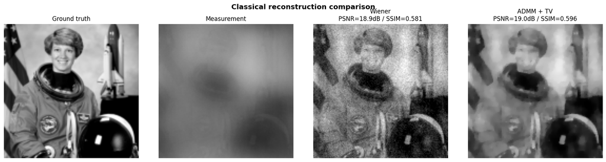

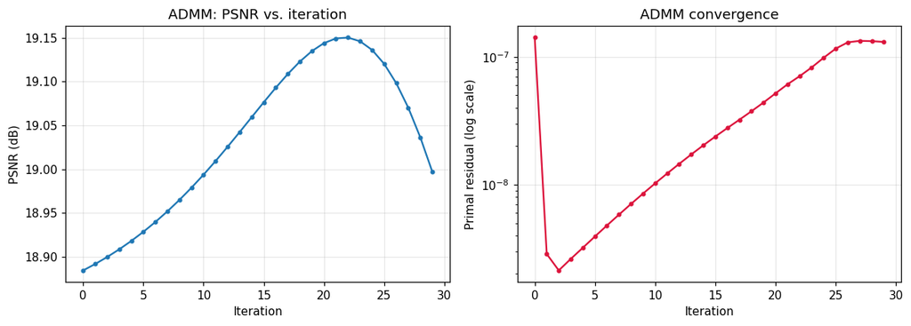

```python
def admm_reconstruct(y, fwd, rho_start=5.0, rho_end=0.2, lam_tv=0.001, n_iters=30, tv_inner=50, ground_truth=None, verbose=False):
    Hc, Habs2 = fwd.psf_fft_conj, fwd.psf_fft_abs_sq
    y_fft = torch.fft.fft2(y.squeeze(1))
    z = wiener_deconv(y, fwd, reg=1e-3)
    u = torch.zeros_like(y)
    rhos = np.geomspace(rho_start, rho_end, n_iters)
    history = []
    for k in range(n_iters):
        rho = float(rhos[k])
        rhs_fft = Hc * y_fft + rho * torch.fft.fft2((z - u).squeeze(1))
        x_new = torch.fft.ifft2(rhs_fft / (Habs2 + rho)).real.unsqueeze(1)
        z_new = tv_prox((x_new + u).clamp(min=0), lam=lam_tv / rho, n_iters=tv_inner).clamp(0, 1)
        u = u + x_new - z_new
        z = z_new

        entry = {'iter': k, 'primal_residual': (x_new - z_new).pow(2).mean().item()}
        if ground_truth is not None:
            entry['psnr'] = compute_psnr(z_new, ground_truth)
        history.append(entry)
        if verbose and (k % 5 == 0 or k == n_iters - 1):
            msg = f"  ADMM iter {k:3d}: primal_res={entry['primal_residual']:.6f}"
            if 'psnr' in entry:
                msg += f"  PSNR={entry['psnr']:.2f} dB"
            print(msg)

    return z, history


print("Running ADMM + TV reconstruction...")
admm_result, admm_history = admm_reconstruct(y_meas, forward_model, rho_start=5.0, rho_end=0.2, lam_tv=0.001, n_iters=30, tv_inner=50, ground_truth=x_gt, verbose=True)

wiener_result = wiener_deconv(y_meas, forward_model, reg=1e-3)

fig, axes = plt.subplots(1, 4, figsize=(16, 4.2))
for ax, img, title in zip(
    axes,
    [scene, y_meas.squeeze().cpu().numpy(), wiener_result.squeeze().cpu().numpy(), admm_result.squeeze().cpu().numpy()],
    ['Ground truth', 'Measurement',
     f'Wiener\nPSNR={compute_psnr(wiener_result, x_gt):.1f}dB / SSIM={compute_ssim(wiener_result, x_gt):.3f}',
     f'ADMM + TV\nPSNR={compute_psnr(admm_result, x_gt):.1f}dB / SSIM={compute_ssim(admm_result, x_gt):.3f}']
):
    ax.imshow(img, vmin=0, vmax=1 if img.max() <= 1.01 else None)
    ax.set_title(title, fontsize=11); ax.axis('off')
plt.suptitle('Classical reconstruction comparison', fontsize=13, fontweight='bold')
plt.tight_layout(); plt.show()

# Convergence plot
fig, (ax1, ax2) = plt.subplots(1, 2, figsize=(11, 4))
iters = [h['iter'] for h in admm_history]
ax1.plot(iters, [h['psnr'] for h in admm_history], 'o-', ms=3); ax1.set_xlabel('Iteration'); ax1.set_ylabel('PSNR (dB)')
ax1.set_title('ADMM: PSNR vs. iteration'); ax1.grid(alpha=0.3)
ax2.semilogy(iters, [h['primal_residual'] for h in admm_history], 'o-', ms=3, color='crimson')
ax2.set_xlabel('Iteration'); ax2.set_ylabel('Primal residual (log scale)'); ax2.set_title('ADMM convergence'); ax2.grid(alpha=0.3)
plt.tight_layout(); plt.show()
```

## Part 5 : Physics-Informed Deep Learning: the Unrolled ADMM Network

**Algorithm unrolling** turns each iteration of an optimization algorithm into a layer of a neural network. We keep the exact same two-step structure as our classical ADMM solver:

| ADMM step | Classical | Unrolled network |
| --- | --- | --- |
| x-update | closed-form Fourier solve, fixed `ρ` | closed-form Fourier solve, **learnable** `ρ` per stage |
| z-update | hand-designed TV proximal operator | **learned CNN denoiser** (much more expressive than TV) |
| Depth | 30–100+ iterations | 4–8 stages (much faster at inference) |

Because the x-update is still the *exact* physics-based least-squares solve (using the real PSF), the network can't ignore the optics, it's forced to stay consistent with the forward model at every stage, while the CNN learns whatever prior best matches the training data. This is the core idea of "physics-informed" reconstruction: model-based structure + learned components, rather than a black-box image-to-image network.

```python
class CNNDenoiser(nn.Module):
    '''Small residual CNN that plays the role of the TV proximal / z-update step.'''

    def __init__(self, channels=1, features=24, n_blocks=2):
        super().__init__()
        self.inp = nn.Conv2d(channels, features, 3, padding=1)
        self.blocks = nn.ModuleList([
            nn.Sequential(
                nn.Conv2d(features, features, 3, padding=1), nn.ReLU(inplace=True),
                nn.Conv2d(features, features, 3, padding=1),
            ) for _ in range(n_blocks)
        ])
        self.out = nn.Conv2d(features, channels, 3, padding=1)

    def forward(self, x):
        h = F.relu(self.inp(x))
        for blk in self.blocks:
            h = h + blk(h)
        return x + self.out(h)   # residual prediction of the clean image


class UnrolledStage(nn.Module):
    '''One unrolled ADMM iteration: physics-based x-update + learned CNN z-update.'''

    def __init__(self, init_rho=1.0, features=24, n_blocks=2):
        super().__init__()
        # parameterize rho through softplus so it always stays positive during training
        self.rho_raw = nn.Parameter(torch.tensor(float(np.log(np.exp(init_rho) - 1))))
        self.denoiser = CNNDenoiser(features=features, n_blocks=n_blocks)

    @property
    def rho(self):
        return F.softplus(self.rho_raw) + 1e-3

    def forward(self, y_fft, psf_fft_conj, psf_fft_abs_sq, z, u):
        rho = self.rho
        rhs_fft = psf_fft_conj * y_fft + rho * torch.fft.fft2((z - u).squeeze(1))
        x_new = torch.fft.ifft2(rhs_fft / (psf_fft_abs_sq + rho)).real.unsqueeze(1)
        z_new = self.denoiser(x_new + u)
        u_new = u + x_new - z_new
        return x_new, z_new, u_new


class UnrolledADMM(nn.Module):
    def __init__(self, psf: np.ndarray, num_stages=5, features=24, n_blocks=2, noise_std=0.003):
        super().__init__()
        fwd = ForwardModel(psf, noise_std=noise_std)
        self.register_buffer('psf_fft_conj', fwd.psf_fft_conj)
        self.register_buffer('psf_fft_abs_sq', fwd.psf_fft_abs_sq)
        init_rhos = [1.0 * (1.5 ** i) for i in range(num_stages)]
        self.stages = nn.ModuleList([
            UnrolledStage(init_rho=r, features=features, n_blocks=n_blocks) for r in init_rhos
        ])

    def forward(self, y, return_intermediates=False):
        y_fft = torch.fft.fft2(y.squeeze(1))
        z = y.clone()
        u = torch.zeros_like(y)
        intermediates = []
        for stage in self.stages:
            x_new, z_new, u = stage(y_fft, self.psf_fft_conj, self.psf_fft_abs_sq, z, u)
            z = z_new
            if return_intermediates:
                intermediates.append(z.detach().clone())
        return (z, intermediates) if return_intermediates else z

    def print_architecture(self):
        n_params = sum(p.numel() for p in self.parameters())
        print("=" * 55)
        print(f"  Unrolled ADMM Network — {len(self.stages)} stages, {n_params:,} parameters")
        print("=" * 55)
        for i, s in enumerate(self.stages):
            print(f"  Stage {i}: initial rho={s.rho.item():.3f}")
        print("=" * 55)


NUM_STAGES, FEATURES, N_BLOCKS = 5, 24, 2
net = UnrolledADMM(psf, num_stages=NUM_STAGES, features=FEATURES, n_blocks=N_BLOCKS, noise_std=NOISE_STD).to(device)
net.print_architecture()
```

```
=======================================================
  Unrolled ADMM Network — 5 stages, 106,450 parameters
=======================================================
  Stage 0: initial rho=1.001
  Stage 1: initial rho=1.501
  Stage 2: initial rho=2.251
  Stage 3: initial rho=3.376
  Stage 4: initial rho=5.063
=======================================================
```

### Training data

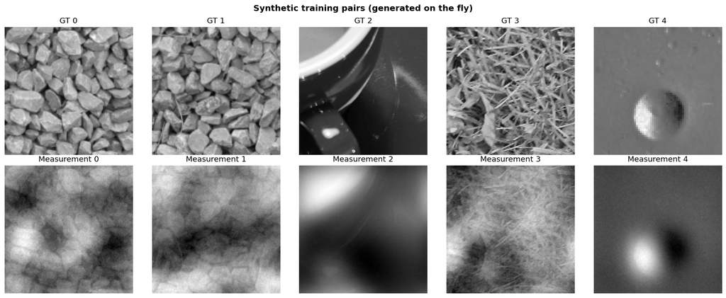

```python
from skimage import data as skdata, transform, color

# a pool of varied real photos shipped inside scikit-image itself — no downloads needed.
# using a mix of textures/subjects so the network sees more than one kind of content.
_IMAGE_POOL_NAMES = ['camera', 'astronaut', 'chelsea', 'coffee', 'brick', 'grass', 'gravel', 'horse', 'moon', 'page']
_IMAGE_POOL = []
for _name in _IMAGE_POOL_NAMES:
    _img = getattr(skdata, _name)()
    if _img.ndim == 3:
        _img = color.rgb2gray(_img)
    _img = _img.astype(np.float32)
    _img = (_img - _img.min()) / (_img.max() - _img.min() + 1e-8)
    _IMAGE_POOL.append(_img)

def _random_real_crop(size, rng):
    img = _IMAGE_POOL[rng.randint(len(_IMAGE_POOL))]
    h, w = img.shape
    if h < size or w < size:
        scale = size / min(h, w) * 1.1
        img = transform.resize(img, (int(h * scale) + 1, int(w * scale) + 1), anti_aliasing=True)
        h, w = img.shape
    top = rng.randint(0, h - size + 1)
    left = rng.randint(0, w - size + 1)
    crop = img[top:top + size, left:left + size]
    if rng.rand() < 0.5:
        crop = crop[:, ::-1]
    if rng.rand() < 0.5:
        crop = crop[::-1, :]
    return np.ascontiguousarray(crop, dtype=np.float32)

def sample_batch(batch_size, size, seed=None):
    rng = np.random.RandomState(seed)
    imgs = np.stack([_random_real_crop(size, rng) for _ in range(batch_size)])
    return torch.from_numpy(imgs).unsqueeze(1).float()
# preview a few training pairs
preview = sample_batch(5, IMG_SIZE, seed=SEED)
with torch.no_grad():
    preview_y = forward_model(preview.to(device))

fig, axes = plt.subplots(2, 5, figsize=(16, 6.5))
for i in range(5):
    axes[0, i].imshow(preview[i, 0].numpy(), vmin=0, vmax=1); axes[0, i].set_title(f'GT {i}'); axes[0, i].axis('off')
    axes[1, i].imshow(preview_y[i, 0].cpu().numpy()); axes[1, i].set_title(f'Measurement {i}'); axes[1, i].axis('off')
plt.suptitle('Synthetic training pairs (generated on the fly)', fontsize=13, fontweight='bold')
plt.tight_layout(); plt.show()
```

```python
# ---- Training loop ----
NUM_EPOCHS      = 100     # bump this up (e.g. 60-100) if you have more time/GPU
STEPS_PER_EPOCH = 25
BATCH_SIZE      = 8
LEARNING_RATE   = 2e-3
LAMBDA_TV       = 0.01   # weight of the TV regularizer added to the training loss

optimizer = torch.optim.Adam(net.parameters(), lr=LEARNING_RATE)
scheduler = torch.optim.lr_scheduler.CosineAnnealingLR(optimizer, T_max=NUM_EPOCHS)

# fixed validation set so PSNR is comparable across epochs
val_gt = sample_batch(16, IMG_SIZE, seed=999).to(device)
with torch.no_grad():
    val_y = forward_model(val_gt)

train_losses, val_psnrs = [], []
print(f"{'Epoch':>5} | {'Train loss':>11} | {'Val PSNR':>9} | {'Time':>6}")
print("-" * 44)

for epoch in range(1, NUM_EPOCHS + 1):
    net.train()
    t0 = time.time()
    epoch_loss = 0.0

    for step in range(STEPS_PER_EPOCH):
        gt = sample_batch(BATCH_SIZE, IMG_SIZE).to(device)
        with torch.no_grad():
            y = forward_model(gt)

        pred = net(y)
        loss = F.mse_loss(pred, gt) + LAMBDA_TV * total_variation(pred)

        optimizer.zero_grad()
        loss.backward()
        torch.nn.utils.clip_grad_norm_(net.parameters(), max_norm=1.0)
        optimizer.step()
        epoch_loss += loss.item()

    scheduler.step()
    avg_loss = epoch_loss / STEPS_PER_EPOCH
    train_losses.append(avg_loss)

    net.eval()
    with torch.no_grad():
        val_pred = net(val_y)
        val_psnr = compute_psnr(val_pred, val_gt)
    val_psnrs.append(val_psnr)

    if epoch % 5 == 0 or epoch == 1 or epoch == NUM_EPOCHS:
        print(f"{epoch:5d} | {avg_loss:11.5f} | {val_psnr:7.2f} dB | {time.time()-t0:5.1f}s")

print("\nTraining complete.")
```

```
Epoch |  Train loss |  Val PSNR |   Time
--------------------------------------------
    1 |     0.06484 |   17.72 dB |   2.3s
    5 |     0.01461 |   19.39 dB |   1.8s
   10 |     0.01270 |   19.57 dB |   1.7s
   15 |     0.01094 |   20.28 dB |   1.7s
   20 |     0.00952 |   20.87 dB |   1.7s
   25 |     0.00846 |   20.90 dB |   1.7s
   30 |     0.00776 |   21.20 dB |   1.8s
   35 |     0.00751 |   21.25 dB |   1.8s
   40 |     0.00765 |   21.45 dB |   1.8s
   45 |     0.00708 |   21.82 dB |   1.8s
   50 |     0.00691 |   22.03 dB |   1.8s
   55 |     0.00680 |   22.25 dB |   1.8s
   60 |     0.00638 |   22.36 dB |   1.9s
   65 |     0.00595 |   22.40 dB |   2.2s
   70 |     0.00608 |   22.39 dB |   2.0s
   75 |     0.00594 |   22.52 dB |   1.9s
   80 |     0.00570 |   22.60 dB |   1.9s
   85 |     0.00578 |   22.68 dB |   1.9s
   90 |     0.00597 |   22.73 dB |   1.9s
   95 |     0.00584 |   22.71 dB |   1.8s
  100 |     0.00563 |   22.72 dB |   1.9s

Training complete.
```

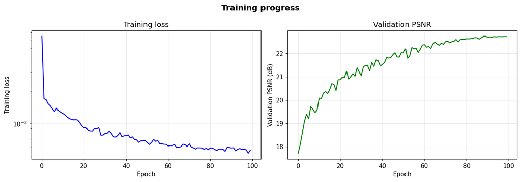

```
Learned rho (ADMM penalty) per stage after training:
  Stage 0: rho = 1.5537
  Stage 1: rho = 1.0347
  Stage 2: rho = 1.8235
  Stage 3: rho = 3.0783
  Stage 4: rho = 4.5644
```

```python
fig, (ax1, ax2) = plt.subplots(1, 2, figsize=(12, 4.2))
ax1.plot(train_losses, 'b-'); ax1.set_yscale('log'); ax1.set_xlabel('Epoch'); ax1.set_ylabel('Training loss')
ax1.set_title('Training loss'); ax1.grid(alpha=0.3)
ax2.plot(val_psnrs, 'g-'); ax2.set_xlabel('Epoch'); ax2.set_ylabel('Validation PSNR (dB)')
ax2.set_title('Validation PSNR'); ax2.grid(alpha=0.3)
plt.suptitle('Training progress', fontsize=13, fontweight='bold')
plt.tight_layout(); plt.show()

print("Learned rho (ADMM penalty) per stage after training:")
for i, s in enumerate(net.stages):
    print(f"  Stage {i}: rho = {s.rho.item():.4f}")
```

## Part 6 — Full Side-by-Side Comparison

```
Method                     |  PSNR (dB) |    SSIM |  Time (s)
--------------------------------------------------------------
Wiener                     |     18.89  | 0.5852  |   0.0007
ADMM + TV                  |     18.50  | 0.5257  |   3.4204
Unrolled ADMM (learned)    |     18.85  | 0.6246  |   0.0126
```

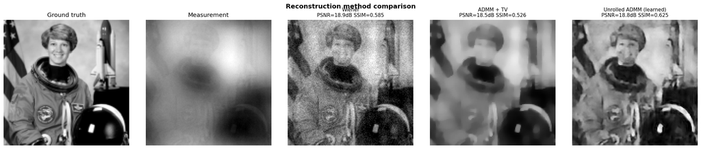

```python
net.eval()
test_scene = load_real_scene("astronaut", 128)
x_test = torch.from_numpy(test_scene)[None, None].to(device)
with torch.no_grad():
    y_test = forward_model(x_test)

results = {}

t0 = time.time()
r_wiener = wiener_deconv(y_test, forward_model, reg=1e-3)
results['Wiener'] = (r_wiener, time.time() - t0)

t0 = time.time()
r_admm, _ = admm_reconstruct(y_test, forward_model, rho_start=5.0, rho_end=0.2, lam_tv=0.001, n_iters=80, tv_inner=50, ground_truth=x_test)
results['ADMM + TV'] = (r_admm, time.time() - t0)

t0 = time.time()
with torch.no_grad():
    r_learned = net(y_test)
results['Unrolled ADMM (learned)'] = (r_learned, time.time() - t0)

print(f"{'Method':<26} | {'PSNR (dB)':>10} | {'SSIM':>7} | {'Time (s)':>9}")
print('-' * 62)
for name, (recon, dt) in results.items():
    p, s = compute_psnr(recon, x_test), compute_ssim(recon, x_test)
    print(f"{name:<26} | {p:9.2f}  | {s:6.4f}  | {dt:8.4f}")

fig, axes = plt.subplots(1, 2 + len(results), figsize=(4 * (2 + len(results)), 4.2))
axes[0].imshow(test_scene, vmin=0, vmax=1); axes[0].set_title('Ground truth'); axes[0].axis('off')
axes[1].imshow(y_test.squeeze().cpu().numpy()); axes[1].set_title('Measurement'); axes[1].axis('off')
for ax, (name, (recon, dt)) in zip(axes[2:], results.items()):
    p, s = compute_psnr(recon, x_test), compute_ssim(recon, x_test)
    ax.imshow(recon.squeeze().cpu().numpy(), vmin=0, vmax=1)
    ax.set_title(f'{name}\nPSNR={p:.1f}dB SSIM={s:.3f}', fontsize=10)
    ax.axis('off')
plt.suptitle('Reconstruction method comparison', fontsize=13, fontweight='bold')
plt.tight_layout(); plt.show()
```

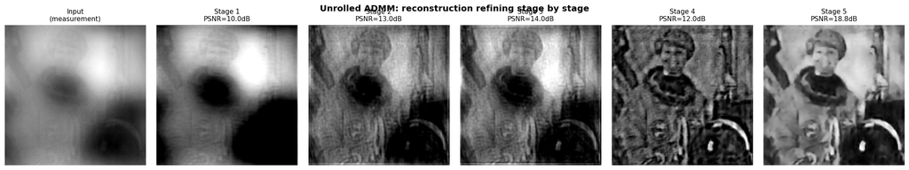

```python
# Visualize how the unrolled network's estimate evolves stage by stage
net.eval()
with torch.no_grad():
    _, stage_outputs = net(y_test, return_intermediates=True)

fig, axes = plt.subplots(1, len(stage_outputs) + 1, figsize=(3.2 * (len(stage_outputs) + 1), 3.6))
axes[0].imshow(y_test.squeeze().cpu().numpy()); axes[0].set_title('Input\n(measurement)', fontsize=10); axes[0].axis('off')
for i, out in enumerate(stage_outputs):
    p = compute_psnr(out, x_test)
    axes[i + 1].imshow(out.squeeze().cpu().numpy(), vmin=0, vmax=1)
    axes[i + 1].set_title(f'Stage {i+1}\nPSNR={p:.1f}dB', fontsize=10)
    axes[i + 1].axis('off')
plt.suptitle('Unrolled ADMM: reconstruction refining stage by stage', fontsize=13, fontweight='bold')
plt.tight_layout(); plt.show()
```

## Summary

[output not shown]

### Ideas for extending this notebook

- Increase `IMG_SIZE`, `NUM_STAGES`, `FEATURES`, and training epochs for higher-fidelity results.
- Swap in a real captured PSF (e.g. from a calibration image of a point source) instead of the simulated one.
- Extend to 3-channel (RGB) scenes and measurements.
- Add a perceptual (VGG-feature) loss term alongside MSE + TV.
- Try training with variable noise levels for a more noise-robust network.
- Compare against a plain black-box U-Net (no physics in the loop) to see how much the physics-informed structure actually helps.